# Import and Preperation

credits where credits due: https://colab.research.google.com/drive/1U0sRZdxVUn8LbQN9KidMaomKt2MPJ2-o#scrollTo=ARsdbx5hqLah

## Grundbegriffe machen das Leben leichter:

- *Dense* erstellt die *Layer*
- *units* sind die einzelnen Nodes
- *epochs* ist die Anzahl der Durchläufe
- *batch* die Korrekturen die durchgeührt werden (je niedriger, desto mehr)

```python
import keras
from keras.datasets import mnist
from keras.layers import Dense
from keras.models import Sequential
from matplotlib import pyplot as plt
from random import randint

# Preparing the dataset
# Setup train and test splits
(x_train, y_train), (x_test, y_test) = mnist.load_data()

# Making a copy before flattening for the next code-segment which displays images
x_train_drawing = x_train

image_size = 784 # 28 x 28
x_train = x_train.reshape(x_train.shape[0], image_size)
x_test = x_test.reshape(x_test.shape[0], image_size)

# Convert class vectors to binary class matrices
num_classes = 10
y_train = keras.utils.to_categorical(y_train, num_classes)
y_test = keras.utils.to_categorical(y_test, num_classes)
```

## So schaun die Daten aus:

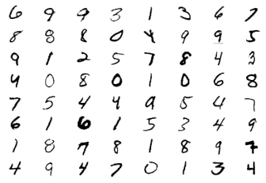

```python
for i in range(64):
    ax = plt.subplot(8, 8, i+1)
    ax.axis('off')
    plt.imshow(x_train_drawing[randint(0, x_train.shape[0])], cmap='Greys')
```

# Jetzt geht's los

## Modelerstellung

- über Sequential
- dann werden layer hinzugefügt wobei die units (.i. nodes) per layer mit angegeben werden
- der zweite add ist der output (daher sind es genau die 10 nodes, die den Ziffern entsprechen
- summary am Ende fürn Überblick

```python
model = Sequential()

# The input layer requires the special input_shape parameter which should match
# the shape of our training data.
model.add(Dense(units=32, activation='sigmoid', input_shape=(image_size,)))
model.add(Dense(units=num_classes, activation='softmax'))
model.summary()
```

```
Model: "sequential_1"
_________________________________________________________________
Layer (type)                 Output Shape              Param #
=================================================================
dense_1 (Dense)              (None, 32)                25120
_________________________________________________________________
dense_2 (Dense)              (None, 10)                330
=================================================================
Total params: 25,450
Trainable params: 25,450
Non-trainable params: 0
_________________________________________________________________
```

## Model Evaluation

- optimizer: sgd (Stochastic gradient descent)
  - wie optimiert wird
- loss function: categorical_crossentropy
  - mit welcher Methode der loss berechnet wird
- metrics: auccuracy
  - wonach optimiert werden soll

Dann wird das Modell auf train gefittet und auf test evaluiert

Darunter dann noch der plot

- NB! in der Vorlage war: ['acc'] und ['val_acc'] angegeben, was zu einem Fehler führte - acc mit accuracy ersetzen hat geholfen (der Name muss mit dem in metrics[] übereinstimmen)

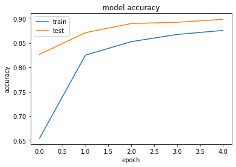

```
Test loss: 0.498
Test accuracy: 0.888
```

```python
model.compile(optimizer="sgd", loss='categorical_crossentropy', metrics=['accuracy'])
history = model.fit(x_train, y_train, batch_size=128, epochs=5, verbose=False, validation_split=.1)
loss, accuracy  = model.evaluate(x_test, y_test, verbose=False)

#plt.plot(history.history['acc'])
#plt.plot(history.history['val_acc'])
plt.plot(history.history['accuracy'])
plt.plot(history.history['val_accuracy'])
plt.title('model accuracy')
plt.ylabel('accuracy')
plt.xlabel('epoch')
plt.legend(['train', 'test'], loc='best')
plt.show()

print(f'Test loss: {loss:.3}')
print(f'Test accuracy: {accuracy:.3}')
```

## Am Schluss das ganze noch in functions umschreiben

damit wir nachher damit rumspielen können

```python
def create_dense(layer_sizes): #create_model
    model = Sequential()
    # Dense ist der layer - die mit add hinzugefügt werden
    model.add(Dense(layer_sizes[0], activation='sigmoid', input_shape=(image_size,)))

    for s in layer_sizes[1:]:
        model.add(Dense(units = s, activation = 'sigmoid'))

    # das ist der final layer (deswegen sind die units die classen - hier: 10)
    model.add(Dense(units=num_classes, activation='softmax'))

    return model

def evaluate(model, batch_size=128, epochs=5):
    model.summary()
    model.compile(optimizer='sgd', loss='categorical_crossentropy', metrics=['accuracy'])
    history = model.fit(x_train, y_train, batch_size=batch_size, epochs=epochs, validation_split=.1, verbose=False)
    loss, accuracy  = model.evaluate(x_test, y_test, verbose=False)

    #plt.plot(history.history['acc'])
    #plt.plot(history.history['val_acc'])
    plt.plot(history.history['accuracy'])
    plt.plot(history.history['val_accuracy'])
    plt.title('model accuracy')
    plt.ylabel('accuracy')
    plt.xlabel('epoch')
    plt.legend(['train', 'test'], loc='best')
    plt.show()

    print()
    print(f'Test loss: {loss:.3}')
    print(f'Test accuracy: {accuracy:.3}')
```